# Day1

# 『Rで学ぶ統計学入門』勉強会

## 概要

- 『Rで学ぶ統計学入門』を教科書として統計学の基本(t検定まで)と 初歩的、応用（8章までと補足）を進める。
- ゴールは統計の全体像を掴んで、とりあえず与えられたデータに対して 適切な手法を選択、実行できるようになること
- **統計学の厳密な部分には立ち入らない**
  - こういうケースで何をすればいいのか、の説明のみ
  - より細かく知りたい場合は教科書の該当部分を参照

## 全体のアウトライン

Day1

- R/RStudio
- t検定
- ANOVA

Day2

- GLM
- ランダム構造
- モデル選択

## Rの環境の説明

- RStudio(Server)の説明
- 基本機能の説明
- data.frame の説明
- このノートブックを見ながら

## 概要

- 『Rで学ぶ統計学入門』を教科書として統計学の基本（4章まで）と初歩的な応用（8章まで）をそれぞれ90分ずつ読み進める。
- 初学者にとって理解が困難な点や、事前に頂いた質問などから、補足する部分や飛ばす部分を決めて進行します。
- 躓くことの多い環境構築の部分や、打ち込むのが面倒なデータの部分はこちらが提供します。
- 対象者は初学者とそうでない人半々. 質問は随時受け付け

ゼミの方向け(7/15,22): 難しい箇所、むしろ飛ばしても構わない箇所など あれば随時Google Formからコメントもらえると助かります。 (コピペしながらがよいのか、ワークシートを用意したほうがよいのか。)

# Ch.1 統計学を学ぶ大切さ

## Ch.1 の目標

- データの解釈を批判的に見てみる
- データの比較に使う記述統計量を思い出す
- R言語を扱う動機を共有し、セットアップをする

## 1.1 TV番組で流れる “実験” の怪しさ

データの解釈を批判的に見てみる練習をしましょう

1. 個人で(1)の第一パラグラフを読み、以下を行ってください。
   - **仮説**と**実験**、**結果**と**解釈**に整理してください。
   - 解釈が妥当か妥当でないか、根拠を考えて整理してください。

## 1.1 TV番組で流れる “実験” の怪しさ

想定解答

1. 妥当 (上がったのは事実なので仮説は支持できる)
2. 妥当でない (時間の効果かもしれないので、なにもしない比較対象のグループが必要)
3. 妥当でない (一人のデータからそんなに強く主張できない)

-> データを比較するときに大切な考え方を次に見ます。

## 1.2 平均とばらつきの療法が重要: 記述統計量

- 差があるときのパターン
  - 本当は同じ平均を持つ(4年生データ)
  - 本当は異なる平均を持つ(6年生データ)
- データの選択（サンプリング）で「本当の値(平均)」からはズレる。
- 手元のデータのばらつきから、本当の平均の範囲を推定できれば議論できそう

例えば…

- 6年生女子の平均は 145–148 の間に95%の確率で入る
- 6年生男子の平均は 144だった
- → 同じグループであるという主張(仮説)を棄却する

## 1.3 統計を学ぶ大切さ: 推定・検定・予測

用語の説明と章との関連を示します。

1. 推定: 2, 3, 4章
2. 検定: 5, 6 章
3. 予測: 8, 9, 10 章

## Rの説明 (pp.1–2)

- オープンソース
- 統計に強い
- 可視化も楽

## Rのセットアップ

1. https://binder.cs.rcos.nii.ac.jp/v2/gh/kishiyamat/r-stats-hands-on/main にアクセス
2. NIIのウェブページで所属機関を[選択]し、ご自身の所属機関で認証(自分用の分析環境が新たに作られます)
3. Files の右側にある New → RStudio をクリック(RStudio が新しいタブで開きます)

## Ch01.md の目標ふりかえり

- データの解釈を批判的に見てみる -> 統計的に主張したい
- データの比較に使う記述統計量を思い出す -> ばらつきから本当の値の範囲をしりたい
- R言語を扱う動機を共有し、セットアップをする -> 完了？

# Ch.2 母集団と標本

## Ch.2 の目標

- 用語を整理する(母集団と標本, 無作為抽出, 母平均$\mu$と母分散$\sigma^2$)
  - 母集団から標本を無作為抽出 -> (母分散を推定) -> 母平均の幅を推定
  - 「t分布」の説明にも必要
- Rを使って計算してみる

## 2.1 母集団と標本の関係

順当に読み進め太字、記号の意味を押さえていく

- 統計の目的: **母集団**の性質（**母平均**、**母分散**）を**標本**から**推定**
- 記号の意味の説明 (わからない値はギリシャ文字に置かれがち)
  - 母平均を$\mu$、母分散を $\sigma^2$
  - 標本平均を $\bar{X}$、標本分散を $s^2$
- 無作為抽出: 標本を母集団からランダムに抽出(p.12)

## 2.2 標本の性質

p.13以降は徐々に数式が増えていくのでRのコードで補足.

```r
# p.13 のデータ
# <- で変数に10の数値を代入、cはconcatenateのc
A <- c(3, 4, 4, 5, 5, 5, 5, 6, 6, 7)
B <- c(1, 2, 4, 4, 5, 5, 5, 6, 8, 10)
# repはrepeat 例. rep("SampleA", 10)
# データフレーム: エクセルのようなもの. 列に要因、行に観測を持つ
df1 <- data.frame(
  values = c(A, B),
  labels = c(rep("SampleA", 10), rep("SampleB", 10))
)
```

※作成した環境にコピペして動かしてみましょう。 (Zoom画面、スライド、RStudio動かすの流石に面倒ですかね？)

## 2.2 標本の性質

最初の行を見る関数(機能)

```r
# 最初の6行を見せて、という意味
head(df1, 6)
```

```
##   values  labels
## 1      3 SampleA
## 2      4 SampleA
## 3      4 SampleA
## 4      5 SampleA
## 5      5 SampleA
## 6      5 SampleA
```

## 2.2 標本の性質

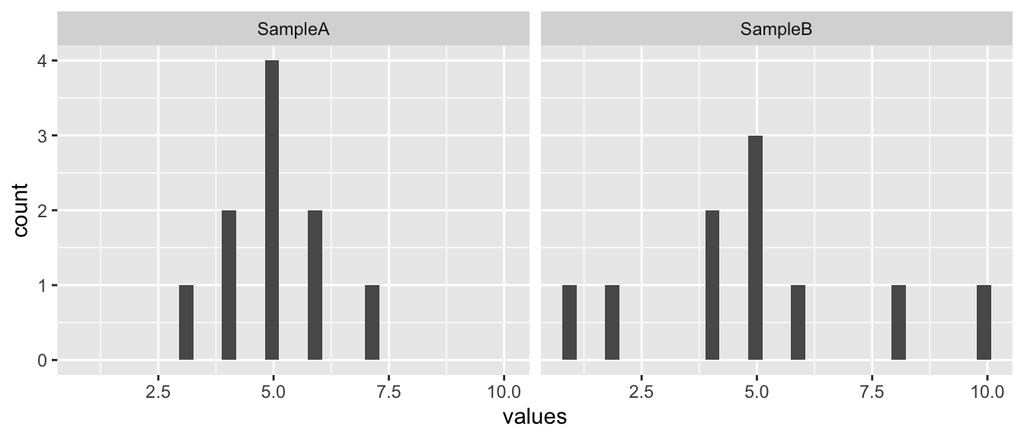

```r
library(ggplot2)  # 可視化
# SampleAもSampleBも5あたりに中心があるけれど、
# ばらつきはSampleBの方が大きいですね。
ggplot(df1) +
  facet_wrap(. ~ labels) +
  geom_histogram(aes(x = values))
```

## 2.2 標本の性質

p.14以降の準備

```r
# https://whatalnk.github.io/stat-intro-by-r-tkd/Chap02.html
A <- c(
  43.3, 43.1, 42.6, 42.4, 42.2, 41.8, 41.7, 41.6, 41.5, 41.4,
  40.8, 40.6, 40.5, 40.4, 40.4, 40.3, 40.2, 39.9, 39.9, 39.8,
  39.7, 39.6, 39.6, 39.5, 39.4, 39.3, 38.9, 38.9, 38.8, 38.8,
  38.7, 38.7, 38.6, 38.6, 38.5, 38.4, 38.3, 38.2, 38.1, 38.1,
  37.6, 37.4, 37.1, 37.8, 37.6, 37.5, 37.4, 37.3, 37.2, 37.1,
  37.1, 36.6, 36.5, 36.5, 36.4, 36.3, 36.2, 36.1, 35.4, 35.3,
  35.2, 35.1, 35.1, 34.7, 34.3, 34.2, 33.2, 33.1, 32.7, 31.5
)
```

## 2.2 標本の性質

p.14以降の準備

```r
# https://whatalnk.github.io/stat-intro-by-r-tkd/Chap02.html
B <- c(
  47.3, 46.1, 45.6, 45.1, 44.5, 44.4, 43.7, 42.6, 42.5, 42.5,
  41.4, 41.8, 41.6, 41.5, 40.7, 40.5, 40.4, 40.3, 40.1, 40.1,
  39.9, 39.8, 39.7, 39.6, 39.6, 39.5, 39.4, 38.9, 38.8, 38.8,
  38.7, 38.7, 38.6, 38.4, 38.2, 38.1, 38.1, 37.8, 37.7, 37.5,
  37.5, 37.4, 37.3, 37.3, 37.1, 36.8, 36.8, 36.7, 36.6, 36.4,
  36.2, 35.4, 35.4, 35.4, 35.3, 35.2, 34.9, 34.8, 34.7, 34.7,
  33.9, 33.8, 33.7, 33.3, 33.1, 32.8, 32.5, 32.1, 31.7, 29.5
)
```

## 2.2 標本の性質

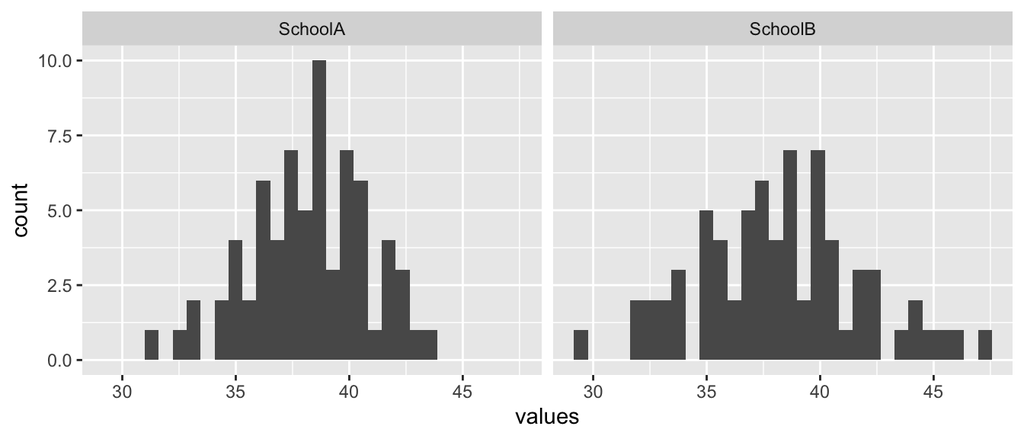

```r
# データフレーム(p.14)
df2 <- data.frame(
  values = c(A, B),
  labels = c(rep("SchoolA", length(A)), rep("SchoolB", length(B)))
)
ggplot(df2) +
  facet_wrap(. ~ labels) +
  geom_histogram(aes(x = values))
```

## 2.2.1 中心や位置を表す指標 (p.15~)

平均値を $\bar{X}=1/n\Sigma_{i=1}^{n}X_i$ としています。 人によっては下のRコードで見たほうが理解しやすいかもしれません。 具体的に、`X_A_bar`(つまり$\bar{X}_\rm{A}$) は以下のように求められます。

```r
X_A_bar = sum(A)/length(A)
X_A_bar
```

```
## [1] 38.23714
```

```r
# 課題: `X_B_bar` を求めてみてください。
```

中央値や最頻値は飛ばします。なお、繰り返しになりますが 母平均は$\mu$、標本平均は$\bar{X}$としています。

## 2.2.2 ばらつきを表す指標(a. 平方和)

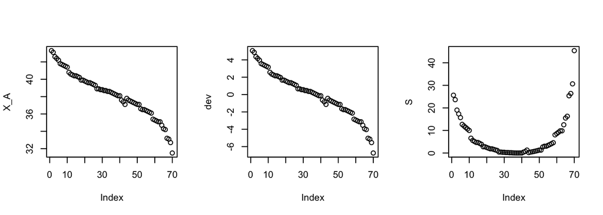

```r
X_A = df2[df2$labels=="SchoolA", "values"]  # 実データ
dev = X_A - mean(X_A)  # 偏差
S = (X_A - mean(X_A))^2  # squared
SS = sum(S)  # 平方和(2.2)
par(mfrow=c(1,3))
plot(X_A)  # 実データ
plot(dev)  # 偏差: 和は打ち消し合って0 -> all.equal(sum(dev), 0)
plot(S)  # 平均で0、外れるほど+
```

## 2.2.2 ばらつきを表す指標(b.c)

- 2. 標本分散SVは標本数で増えるのでnや(n-1)で割る
- 3. 標準偏差$\sqrt{s^2}$ ($\sigma$ではない)
- 不偏分散$s^2$ は(n-1)で割る コラム2.3を参照

```r
SS = sum(S)  # 平方和(2.2)
n = length(X_A)
SV = SS/(n-1)  # 標本分散
sqrt(SV)  # 標準偏差
```

```
## [1] 2.593256
```

```r
sd(X_A) == sqrt(sum((X_A - mean(X_A))^2)/(n-1))  # Rのsdはn-1バージョン
```

```
## [1] TRUE
```

## 2.3 Rを使って計算してみよう

RStudioのコンソールに打ち込んで練習しましょう。

```r
d = c(1,2,3,4,5,6,7,8,9,10)
mean(d)
```

```
## [1] 5.5
```

```r
var(d)  # 不偏分散
```

```
## [1] 9.166667
```

```r
sd(d)  # 標準偏差
```

```
## [1] 3.02765
```

## 演習問題

答えは次ページ

```r
data = c(5.1, 7.4, 10.3, 9.2, 6.5, 6.1, 7.9, 8.4, 8.1, 9.4)
# 2.1
# 2.2
```

## 演習問題(2.1)

```r
data = c(5.1, 7.4, 10.3, 9.2, 6.5, 6.1, 7.9, 8.4, 8.1, 9.4)
# 2.1
mean(data)  # 平均値: [1] 7.84
```

```
## [1] 7.84
```

```r
var(data)  # 不偏分散: [1] 2.582667
```

```
## [1] 2.582667
```

```r
sqrt(var(data))  # 標準偏差: [1] 1.607068
```

```
## [1] 1.607068
```

## 演習問題(2.2)

```r
data = c(5.1, 7.4, 10.3, 9.2, 6.5, 6.1, 7.9, 8.4, 8.1, 9.4)
# 2.2
n = length(data)
d.mean = sum(data)/n  # 平均値: [1] 7.84
d.var = sum((data - d.mean)^2)/(n-1)  # 不偏分散: [1] 2.582667
d.sd = sqrt(d.var)  # 標準偏差: [1] 1.607068
print(c(d.mean, d.var, d.sd))
```

```
## [1] 7.840000 2.582667 1.607068
```

一旦質問の時間

## Ch.2 の目標

- 用語を整理する(母集団と標本, 無作為抽出, 母平均$\mu$と母分散$\sigma^2$)
  - 母集団から標本を無作為抽出 -> (母分散を推定) -> 母平均の幅を推定
  - 「t分布」の説明にも必要
- Rを使って計算してみる

# Ch.3 大数の法則、正規分布、中心極限定理

## Ch.3 の目標

- 大数の法則: 標本サイズが大きくなると平均は母集団平均に近づく(p.28まで)
- 正規分布の定義はさておき、正規分布の性質には慣れる
- 中心極限定理で「平均が集まって作られる分布」という概念に慣れる
- Rで分布

## 3.1 大数の法則

p.28まで

大数の法則: 標本サイズが大きくなると平均は母集団平均に近づく

- 以下の2つを比べたとき、大抵の場合は後者のほうが0.5(母集団平均)に近い
  - 10回のコイントスで平均を求める
  - 10000回のコイントスで平均を求める
- 回数を大きくすると、0.5(母集団平均)に近づくというシミュレーションをしている。

## 3.2 正規分布

定義自体は(3.6)だが以下の性質が大事

- 図3.4が示す通り、平均と標準偏差によって形が変わる
- 先の下側の面積は1になる
- 平均+-2x標準偏差の範囲が約0.95
- 製造した缶の重さなどなど、多くのデータが従う

```r
mean = 10
sd = 2
# 平均から2sdに収まる確率は、mean+2*sd から mean-2*sd を引けば良い
# pnormで与えたmeanとsdの分布におけるxまでの面積を求めくれる
# pnorm(-Inf, mean=mean, sd=sd)  # ->0
# pnorm(Inf, mean=mean, sd=sd)  # ->1
pnorm(mean+2*sd, mean=mean, sd=sd)-pnorm(mean-2*sd, mean=mean, sd=sd)
```

```
## [1] 0.9544997
```

## 3.3 中心極限定理

1. とある特性(平均$\mu$としましょう)を持った母集団を用意します。
2. 母集団から(例えば)10のデータを取り平均$X_\rm{A}$を求め、これを一試行とします。
3. 上の試行をたくさん(教科書でいうところの$M$回)して$X_\rm{A, B, ...}$すると、
   - $X_\rm{m}$は$\mu$を平均とする正規分布に従います。
   - 一試行のサンプル数(上だと10)が小さいと収束が悪くなります。

-> これが「平均が集まって作られる分布」という概念です。 データが正規分布に従っているかは qqnormを使って見る方法や、 統計的に検証する方法があります(後述)。

## 演習問題(3x2分)

3.2は飛ばした二項分布なのでパス(dbinomを使う)

```r
# 3.1 (1)
# 3.1 (2)
```

## 演習問題

```r
# 3.1(1)
mean = 145.8
sd = 4
1000*(pnorm(156, mean=mean, sd=sd)  - pnorm(153, mean=mean, sd=sd))
```

```
## [1] 30.54417
```

```r
# 30
```

## 演習問題

```r
# 3.1(2)
mean = 145.8
sd = 4
1000*(pnorm(mean+2*sd, mean=mean, sd=sd)  - pnorm(mean, mean=mean, sd=sd))
```

```
## [1] 477.2499
```

```r
# 477
```

## Ch.3 の目標

- 大数の法則: 標本サイズが大きくなると平均は母集団平均に近づく(p.28まで)
- 正規分布の定義はさておき、正規分布の性質には慣れる
- 中心極限定理で「平均が集まって作られる分布」という概念に慣れる
- Rで分布

# Ch.4 推定と誤差

## Ch.4 の目標

- 手元のデータに基づいて、真の分布の平均値が95%の確率で入る範囲を知りたい
  - 例えば、真の分布の平均値は95%の確率で130–135cmに入る、など。
  - → 129や136は5%未満の確率→統計的に異なるグループです…と主張できる
- そのためには、平均の分布の標準偏差（標準誤差）が必要
- $t$検定に触れてみる

## 標準誤差

標本平均の分布の標準偏差を「標準誤差$s_{\bar{X}}$」と言います。式(4.1)で定義されます(p.37)。

- nが大きいほど小さくなる -> 図4.2
- 標本標準偏差$s$が小さいほど小さくなる -> 図4.3 (cf.図4.2)

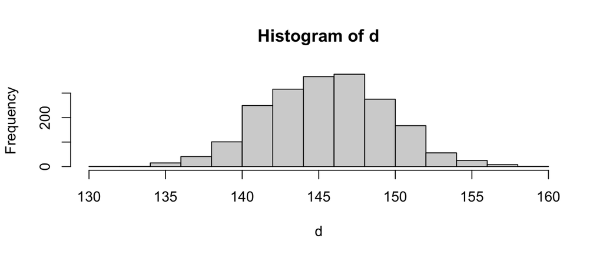

```r
d = rnorm(2000, mean=145.5, sd=4.0)  # 母集団
hist(d)
```

## 4.2 正規分布とt分布

- 式(4.2)の$u$は定義から以下の性質があります。
  - $u$は標本平均が母平均$\mu$と同じ時に0になる
  - $u$は標本平均が標準偏差と同じ時に1になる
  - 標準正規分布N(0,1)に従う
  - → 「155cmというデータがある$\mu$（例えば145.5）の分布から出てきた、仮説を提案します。 でも、その確率は5%未満みたいでう。起こりそうもないので棄却します」 という論法が使える。
- しかし現実に(4.2)にある$\sigma^2$は不明なので、 代わりに$s^2$を使って$u$ではなく$t$を定義します。
  - 分母は標準誤差$s_{\bar{X}}$です。
  - $t$は標準正規分布ではなく、よく似た$t$分布に従います。 「自由度」によって多少、形は変わります。
  - → おなじ論法が使える

注意: 式(4.2)は$t$分布分布の式ではありません。$t$分布に従う値、 $t$値の式です。式(4.2)が正規分布の式(3.6)でないのと同じことです。

## 4.3 95%信頼区間と1標本のt検定

- (4.3)を変形すると(4.4)になります。
  - $t_{(n-1, \alpha/2)}$ とは $n-1$、つまり「自由度」に従う$t$分布を用意した際、 0.05/2、つまり左から0.025%を含む$t$を教えて、という意味
  - 図4.4を見ると、たしかに-2.7は左端になっている。
  - (4.4)の範囲に$\mu$は95%の確率で入る （図4.5は仮想的に20回の実験をして、 95%信頼区間に平均が19回入ることを示している。 あるグループが枠の外ならば、別のグループのデータだと主張できそう）

```r
n=5
qt(0.025, df=n-1)
```

```
## [1] -2.776445
```

## 4.3 95%信頼区間と1標本のt検定

ここでの$p$は145.5を$\mu$とした分布からxという標本（以上に外れた標本）が得られる確率になる。 (4.3)に必要なパーツは揃っているので、自力で求めれる。

```r
n = 20
x = sample(d, n, replace=F)
t.test(x, mu=145.5)
```

```
##
##  One Sample t-test
##
## data:  x
## t = 0.43149, df = 19, p-value = 0.671
## alternative hypothesis: true mean is not equal to 145.5
## 95 percent confidence interval:
##  143.8140 148.0617
## sample estimates:
## mean of x
##  145.9379
```

## 4.3 95%信頼区間と1標本のt検定

こちらは違う母集団なので、棄却したい。

```r
d2 = rnorm(2000, mean=147.5, sd=2.0)  # 母集団
x2 = sample(d2, n, replace=F)
t.test(x2, mu=145.5)  # sdで変わる
```

```
##
##  One Sample t-test
##
## data:  x2
## t = 5.3007, df = 19, p-value = 4.079e-05
## alternative hypothesis: true mean is not equal to 145.5
## 95 percent confidence interval:
##  147.0290 149.0244
## sample estimates:
## mean of x
##  148.0267
```

## 4.4 t値と両側検定

自由度dfに従う$t$分布において、ある確率$p$までを含む$t$を 求めてくれる関数

```r
qt(0.025, df=19)
```

```
## [1] -2.093024
```

```r
qt(0.975, df=19)
```

```
## [1] 2.093024
```

## 演習問題4.1

まず(1)に取り組む

```r
# 4.1
data = c(15.2, 11.3, 15.7, 18.2, 12.4, 13.0, 16.6, 17.3, 16.2, 18.7, 14.5, 13.7)
# (1)
# (2)
```

## 演習問題4.1

(1)の答え合わせ。次は(2)

```r
# 4.1: 式(4.1)
data = c(15.2, 11.3, 15.7, 18.2, 12.4, 13.0, 16.6, 17.3, 16.2, 18.7, 14.5, 13.7)
# (1)
n = length(data)
s_x = sd(data)/sqrt(n)
```

## 演習問題4.1

(2)の答え合わせ

```r
# 4.1: 式(4.1)
data = c(15.2, 11.3, 15.7, 18.2, 12.4, 13.0, 16.6, 17.3, 16.2, 18.7, 14.5, 13.7)
# (1)
n = length(data)
s_x = sd(data)/sqrt(n)
# (2)
p=0.05
X_bar = mean(data)
cred_low = X_bar+qt(p/2, n-1)*s_x
cred_high = X_bar+qt(1-p/2, n-1)*s_x
print(c(cred_low, cred_high))
```

```
## [1] 13.75579 16.71088
```

## 演習問題4.2

## 演習問題4.2

いえる

1. 仮説を「真の平均=13.5」とする
2. 真の平均13.5で信頼区間を作成する
3. データ平均15.23は信頼区間の右側にはずれている
4. 「真の平均=13.5」を棄却し、対立仮説「有意に大きい」を支持

```r
cred_low = 13.5+qt(p/2, n-1)*s_x
cred_high = 13.5+qt(1-p/2, n-1)*s_x
print(c(cred_low, cred_high, X_bar))
```

```
## [1] 12.02246 14.97754 15.23333
```

## 演習問題4.3

ヒント: qtではなくdtをつかう(p.45)

## 演習問題4.3

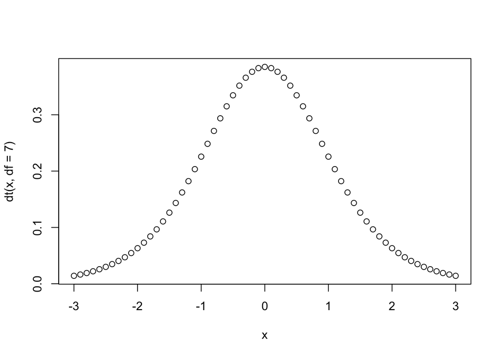

```r
x = seq(-3, 3, 0.1)
plot(x, y=dt(x, df=7))
```

```r
# print(qt(0.975, df=7))
# print(qt(0.025, df=7))
```

## 演習問題4.3

```r
x = seq(-3, 3, 0.1)
# plot(x, y=dt(x, df=7))
print(qt(0.975, df=7))
```

```
## [1] 2.364624
```

```r
print(qt(0.025, df=7))
```

```
## [1] -2.364624
```